# Final Report

Suvarna Moharir, Jaekeun Lee, and Chimaobi Amadi . 07-February-2020

# Finding the best predictors of the per-night Airbnb price in Quebec City, QC.

## Summary

In our model, we built a regression model using a Random Forest Regressor, XGB Regressor, and Support Vector Regression, along with cross-validation with GridSearchCV. The best model (best test score) was the Random Forest Regressor. We did not implement model selection and features engineering, but plan to incorporate these concepts as well as test reproducibility of our findings on other AirBnb datasets.

## Introduction

The Airbnb rental market has grown immensely since its inception in 2008. As of 2019, there are more than 7 million listings worldwide, and on average, there are 2 million people staying in an Airbnb per night (Airbnb (2019)). Those renting out their properties as Airbnbs are called hosts, and are able to set and adjust their own prices. These often serve as an important source of secondary, or even primary income for hosts. There are many different factors that determine whether an individual will choose to rent an Airbnb or not, and new hosts often struggle with setting a fair and competitive price. There have been some peer-reviewed studies done in the past examining what the most important predictors are, and results range from host reviews (Teubner, Hawlitschek, and Dann (2017)) to the host having a profile picture (Ert, Fleischer, and Magen (2016)).

Here, we try to determine the most important predictors for the per-night price of an Airbnb in Quebec City. Answering this question is important because it could help new hosts determine what price to set their rental at, as well as could help existing hosts determine what the most high-yield improvements could be if they would like to raise the per-night price of their unit.

## Methods

### Data

The data set used in this project is from Airbnb. Each year, Airbnb publishes data on their website for all the listings made that year, separated by major city. We used the Quebec City data set, as it is a Canadian city with a wide range of rental prices.

The data contain many features, including the unit’s geographic coordinates, the hosts’ average ratings, and the number of beds in the unit.

We dropped all columns where all of the values were `NULL` or `NaN`. We also dropped all columns that were in French (as this was a Quebec data set). We then dropped rows with missing values; we chose not to replace these values with the mean/median in an attempt to avoid adding ambiguity to the analysis. The remaining rows and columns were split into an 80-20 train-test split, and were then preprocessed using sklearn’s `StandardScaler` (for numeric features) and `OneHotEncoder` (for categorical features).

In total, there are about 45 columns and 2,194 rows that we utilized in our review after removing blank/NaN-filled columns and rows. Each row in the data set is for a separate listing in Quebec City.

### Exploratory Data Analysis (EDA)

During our exploratory data analysis, we generated scatter plots in order to examine the relationship of price with our other features. The features did not appear to have a linear relationship with our response variable, but, as expected, some of the other predictors were highly correlated with each other (e.g. `bedrooms` (the number of bedrooms), and `beds` (the number of beds)).

Shown below is an example of a plot from the EDA, displaying the lack of linear relationships:

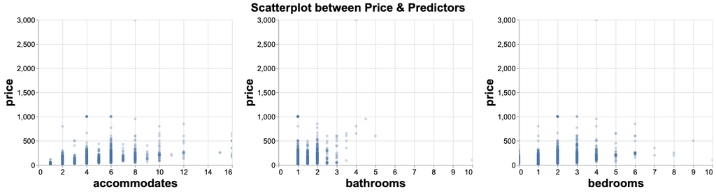

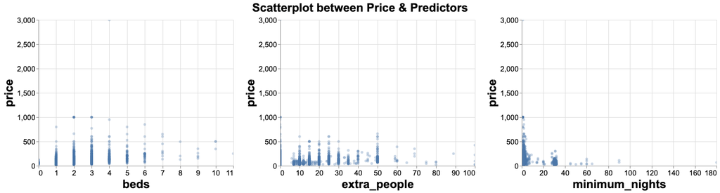

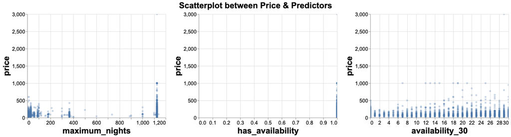

*Figure 1.1: Plot from exploratory data analysis displaying relationships between response (price) and some features.*

From these distributions, it was clear that a multiple linear regression model would not be a good fit for our data. Thus, other regression methods (Random Forest Regression, XGB Regression, Support Vector Regression) were taken into consideration.

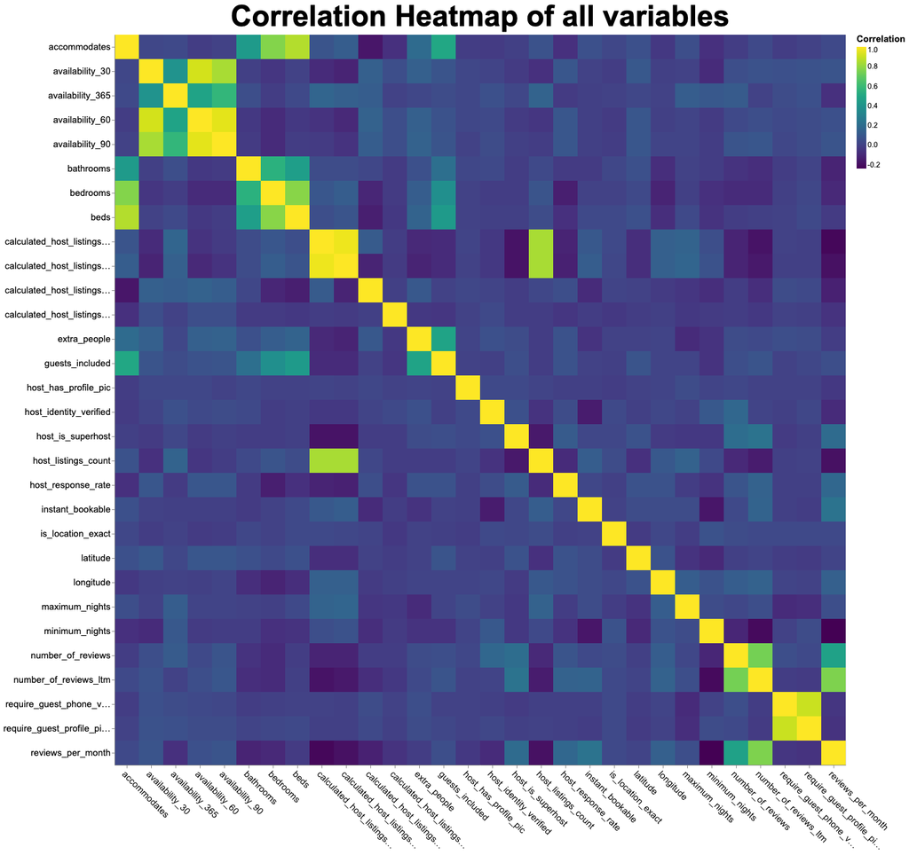

### Analysis

For our model prediction, we chose the 3 aforementioned models (Random Forest Regressor, XGBRegressor, and Support Vector Regressor) as our models, in conjunction with a cross validation technique using GridSearchCV. Cross validation helped in tuning different parameters to ensure optimal choice and results.

The R (R Core Team (2019)) and Python (Van Rossum and Drake (2009)) programming languages and the following R and Python packages were used to perform the analysis: Xgboost(Chen and Guestrin (2016)), docopt(de Jonge (2018)), Matplotlib (Hunter (2007)), tidyverse (Wickham (2011)), Pandas (McKinney and others (2011)), Altair (VanderPlas et al. (2018)), scikit-learn (Pedregosa et al. (2011)), Numpy (Walt, Colbert, and Varoquaux (2011)), feather (McKinney (2019)), and selenium(Percival (2014)).

The code used to perform the analysis and create this report is available [here](https://github.com/UBC-MDS/DSCI_522_Group313).

## Results and Discussion

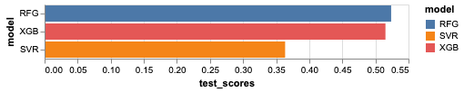

*Figure 2: This graph shows that the Random Forest Regressor had the highest test accuracy, which is why we chose that model to move forward with. XGBoost, and especially SVR, had lower test accuracies than the Random Forest Regressor, and were thus eliminated from consideration.*

The best set of hyperparameters for the best model, Random Forest Regressor, are: - `max_depth`: 25; the maximum depth of the tree is 25.

- `max_features`: `sqrt`; the number of features to consider when looking for the best split is the square root of the number of features.
- `min_samples_split`: 2; the minimum number of samples required to split an internal node is 2. - `n_estimators`: 100; the number of trees in the forest is 100.

The following image summarizes the top 10 features as well as their feature scores:

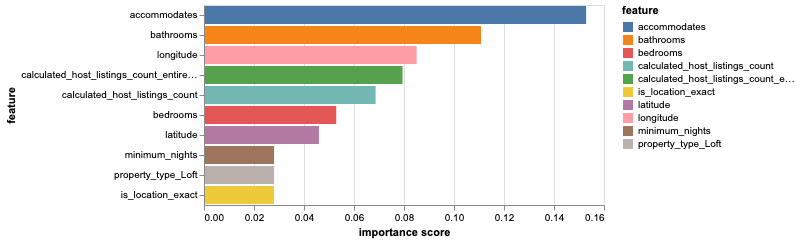

*Figure 3: Summary of the 10 most important features from the Random Forest Regressor, as well as their feature scores.*

Some limitations of this model include the fact that feature engineering was not used, and this may have resulted in a less accurate model. Additionally, random forest regressors have a tendency to be less interpretable. For a larger data set, it may use up a lot of memory. Additionally, random forests have a tendency to overfit; we tuned the hyperparameters in an attempt to resolve this. Finally, some of our “most important features”, namely `calculated host_listings_count_entire_homes` and `calculated_host_listings_count` are largely irrelevant to our research question.

To improve this model in the future, we we will implement model selection and feature engineering so as to focus on the important features. We will also look into dropping the aforementioned irrelevant columns during the preprocessing stage.

Another next step involves re-doing these analyses on other, larger Airbnb datasets (e.g. Vancouver) to observe whether these “most-important predictors” are generalizable to other datasets, or only apply to the Quebec City data set.

## References

Airbnb. 2019. “Airbnb Fast Facts.”

Chen, Tianqi, and Carlos Guestrin. 2016. “Xgboost: A Scalable Tree Boosting System.” In *Proceedings of the 22nd Acm Sigkdd International Conference on Knowledge Discovery and Data Mining*, 785–94.

de Jonge, Edwin. 2018. *Docopt: Command-Line Interface Specification Language*. https://CRAN.R-project.org/package=docopt.

Ert, Eyal, Aliza Fleischer, and Nathan Magen. 2016. “Trust and Reputation in the Sharing Economy: The Role of Personal Photos in Airbnb.” *Tourism Management* 55. Elsevier: 62–73.

Hunter, John D. 2007. “Matplotlib: A 2D Graphics Environment.” *Computing in Science & Engineering* 9 (3). IEEE Computer Society: 90–95.

McKinney, Wes. 2019. *Feather: Simple Wrapper Library to the Apache Arrow-Based Feather File Format*. https://github.com/wesm/feather.

McKinney, Wes, and others. 2011. “Pandas: A Foundational Python Library for Data Analysis and Statistics.” *Python for High Performance and Scientific Computing* 14 (9).

Pedregosa, Fabian, Gaël Varoquaux, Alexandre Gramfort, Vincent Michel, Bertrand Thirion, Olivier Grisel, Mathieu Blondel, et al. 2011. “Scikit-Learn: Machine Learning in Python.” *Journal of Machine Learning Research* 12 (Oct): 2825–30.

Percival, Harry. 2014. *Test-Driven Development with Python: Obey the Testing Goat: Using Django, Selenium, and Javascript*. " O’Reilly Media, Inc.".

R Core Team. 2019. *R: A Language and Environment for Statistical Computing*. Vienna, Austria: R Foundation for Statistical Computing. https://www.R-project.org/.

Teubner, Timm, Florian Hawlitschek, and David Dann. 2017. “Price Determinants on Airbnb: How Reputation Pays Off in the Sharing Economy.” *Journal of Self-Governance & Management Economics* 5 (4).

VanderPlas, Jacob, Brian Granger, Jeffrey Heer, Dominik Moritz, Kanit Wongsuphasawat, Arvind Satyanarayan, Eitan Lees, Ilia Timofeev, Ben Welsh, and Scott Sievert. 2018. “Altair: Interactive Statistical Visualizations for Python.” *Journal of Open Source Software* 3 (32): 1057.

Van Rossum, Guido, and Fred L. Drake. 2009. *Python 3 Reference Manual*. Scotts Valley, CA: CreateSpace.

Walt, Stéfan van der, S Chris Colbert, and Gael Varoquaux. 2011. “The Numpy Array: A Structure for Efficient Numerical Computation.” *Computing in Science & Engineering* 13 (2). IEEE Computer Society: 22–30.

Wickham, Hadley. 2011. “Testthat: Get Started with Testing.” *The R Journal* 3 (1): 5–10.